# Case Study 2: University tuition

Kelly Bodwin

## Get the data

We will be attempting to find a linear regression that models college tuition rates, based on a dataset from US News and World Report. Alas, this data is from 1995, so it is very outdated; still, we will see what we can learn from it.

### Question 1:

1. The dataset is located at `http://kbodwin.web.unc.edu/files/2016/09/tuition_final.csv`; figure out how to use the code you were given last time for `read.csv( )` and `read.table( )` to read the data into **R** and call it `tuition`. Use the functions we learned last time to familiarize yourself with the data in `tuition`.

```r
  # YOUR CODE HERE
tuition = read.csv("http://kbodwin.web.unc.edu/files/2016/09/tuition_final.csv")
```

2. Make a new variable in `tuition` called `Acc.Rate` that contains the acceptance rate for each university.

```r
  # YOUR CODE HERE
tuition$Acc.Rate<- tuition$Accepted/tuition$Applied
```

3. Find and print the row of the data that corresponds to UNC (“University of North Carolina at Chapel Hill”).

```r
  # YOUR CODE HERE
tuition[tuition$Name == "University of North Carolina at Chapel Hill",]
```

```
##       ID                                        Name State Public Avg.SAT
## 682 2974 University of North Carolina at Chapel Hill    NC      1    1121
##     Avg.ACT Applied Accepted  Size Out.Tuition Spending  Acc.Rate
## 682      NA   14596     5985 14609        8400    15893 0.4100438
```

## Question 7:

1. The variable `Spending` contains the expenditure of the school per student. Suppose we want to make a regression that predicts tuition cost from the expenditure per student. Make a linear model for `Spending` versus `Out.Tuition`. Comment on the summary of the model, and plot it on an appropriate scatter plot. Does the model seem to be a good fit for this data?

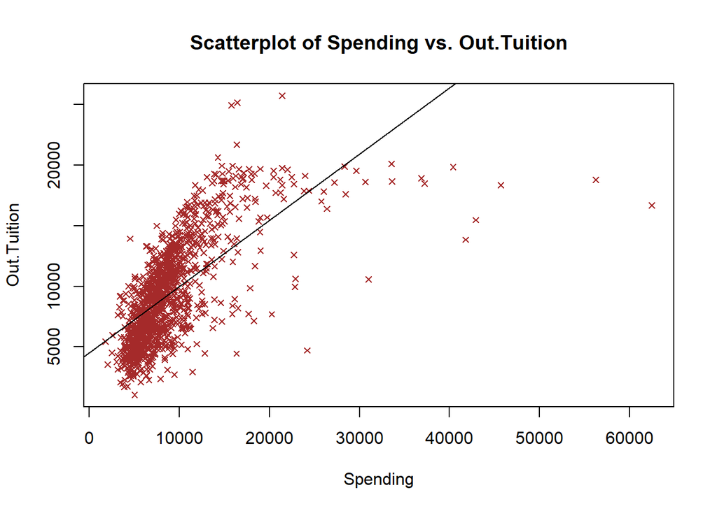

```r
  # YOUR CODE HERE

lm_svt = lm(Out.Tuition ~ Spending , data = tuition)


plot(tuition$Spending, tuition$Out.Tuition, main = "Scatterplot of Spending vs. Out.Tuition", xlab = "Spending", ylab = "Out.Tuition", pch = 4, cex = .75, col = "brown")
abline(lm_svt, col = "black")
```

```r
summary(lm_svt)
```

```
##
## Call:
## lm(formula = Out.Tuition ~ Spending, data = tuition)
##
## Residuals:
##      Min       1Q   Median       3Q      Max
## -22023.7  -2205.4    -99.9   2020.6  11804.0
##
## Coefficients:
##              Estimate Std. Error t value Pr(>|t|)
## (Intercept) 4.477e+03  1.792e+02   24.98   <2e-16 ***
## Spending    5.481e-01  1.752e-02   31.29   <2e-16 ***
## ---
## Signif. codes:  0 '***' 0.001 '**' 0.01 '*' 0.05 '.' 0.1 ' ' 1
##
## Residual standard error: 3126 on 1242 degrees of freedom
##   (58 observations deleted due to missingness)
## Multiple R-squared:  0.4409, Adjusted R-squared:  0.4404
## F-statistic: 979.3 on 1 and 1242 DF,  p-value: < 2.2e-16
```

```
based on the r-squared value and the scatterplot, the linear model doesn't seems to fit the data very well and needs to be adjusted(.4409).
```

2. Plot the residuals versus the values of `Spending`. Do you notice any issues? *Hint: Use your own function `predict_yval()` or the built-in function `predict(my_lm)`. You will need to think about the problem of missing data (`NA`s).*

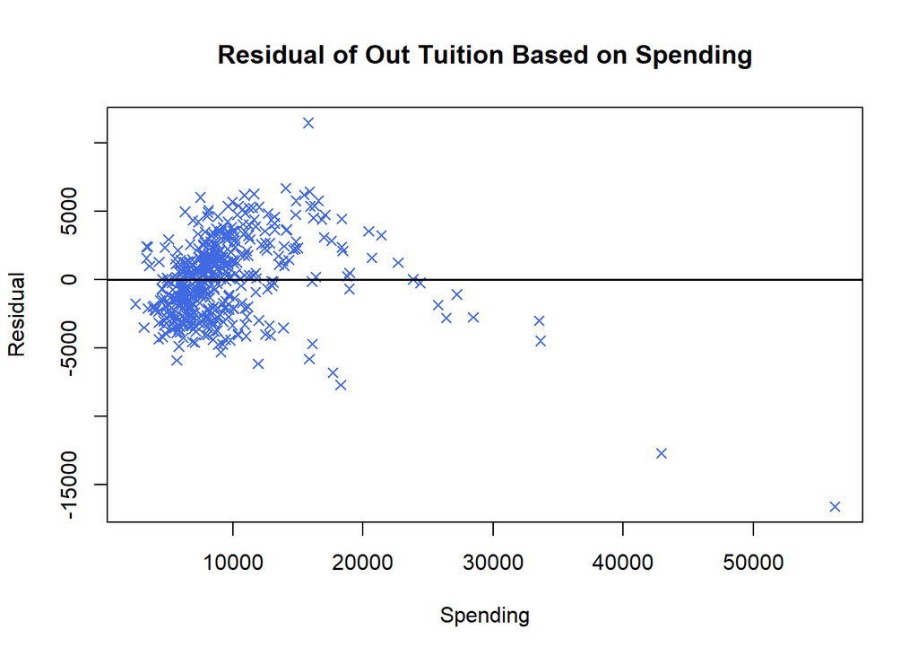

```
The residual plot is not very symmetrical, as most points are clustered to the left with a some points to the right. The plot looks pretty random but the few points on the right are causing problems in the data.
```

```r
  # YOUR CODE HERE
new_data<- na.omit(tuition, cols=c("Spending", "Out.Tuition"))
new_lm <- lm(Out.Tuition~Spending, data =new_data)
new_data$predicted_y = predict(new_lm)
new_data$residual <- new_data$Out.Tuition - new_data$predicted_y

plot(new_data$Spending,new_data$residual,pch=4,bg="red",col="royal blue", main="Residual of Out Tuition Based on Spending", xlab="Spending",ylab="Residual")
abline(0,0,lw= 1.5)
```

3. Use `plot()` to look at the automatic diagnostics. What is each plot showing? What seems to be going wrong here? Which schools are marked as outliers?

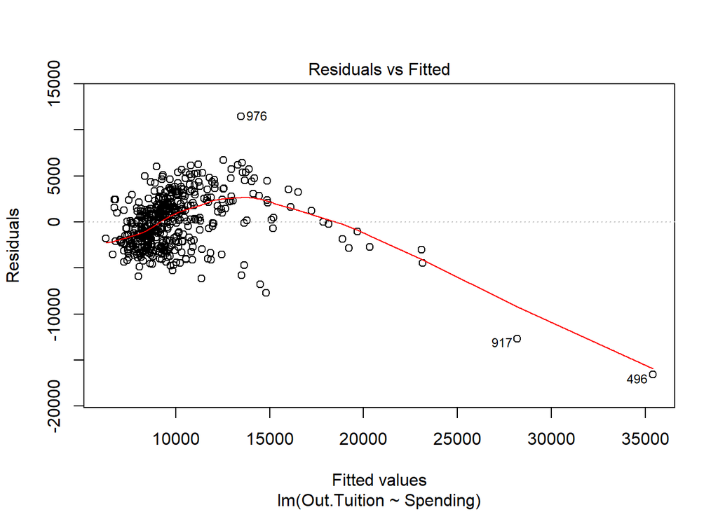

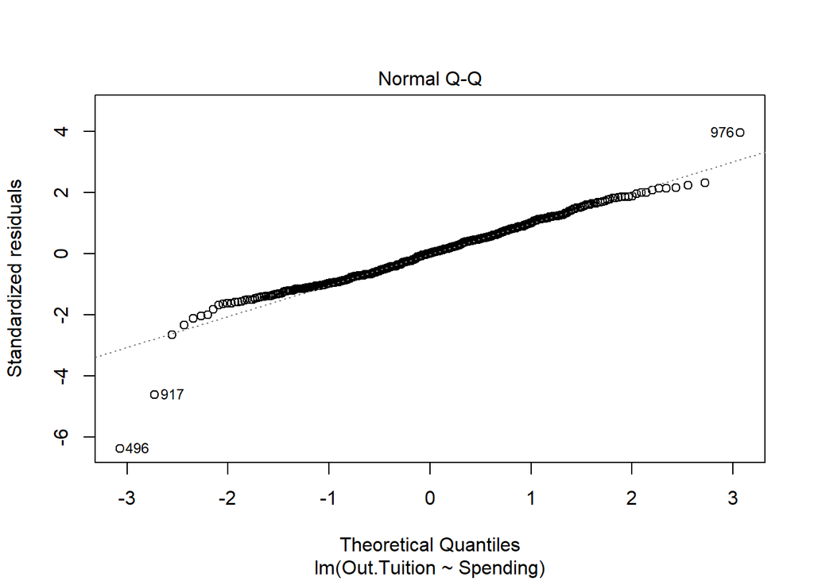

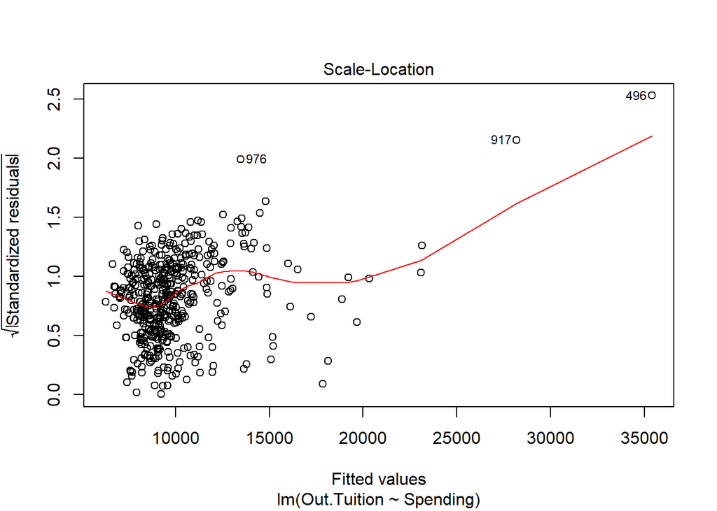

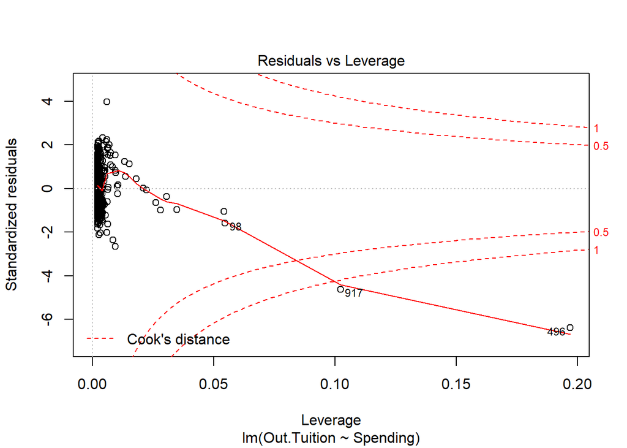

```
917(Antioch),496(Johns Hopkins),976(Franklin and Marshall George) are the schools marked as outliers. There are clear outliers that are affecting the shape of the residual plot; this is also seen in the qq plot with outliers deviating far from the line in the qq plot.
```

```r
  # YOUR CODE HERE
  plot(new_lm)
```

4. Roughly speaking, an outlier is “influential” if it changes the regression line when you remove it. Decide for yourself which data points are influential outliers. Recalculate the linear model without any outliers, and plot it on a scatterplot.

```r
  # YOUR CODE HERE
  outlier_rm = new_data[-c(917,496,976),]
  plot = plot(new_data$Spending,new_data$Out.Tuition,pch=4,col="brown")
  rm_out= lm(Out.Tuition~Spending, data = new_data)
  summary(rm_out)
```

```
##
## Call:
## lm(formula = Out.Tuition ~ Spending, data = new_data)
##
## Residuals:
##      Min       1Q   Median       3Q      Max
## -16603.7  -2075.0     23.1   1870.6  11465.4
##
## Coefficients:
##              Estimate Std. Error t value Pr(>|t|)
## (Intercept) 4.908e+03  2.844e+02   17.25   <2e-16 ***
## Spending    5.423e-01  2.722e-02   19.92   <2e-16 ***
## ---
## Signif. codes:  0 '***' 0.001 '**' 0.01 '*' 0.05 '.' 0.1 ' ' 1
##
## Residual standard error: 2900 on 467 degrees of freedom
## Multiple R-squared:  0.4595, Adjusted R-squared:  0.4583
## F-statistic:   397 on 1 and 467 DF,  p-value: < 2.2e-16
```

```r
  abline(rm_out, lw=2)
```

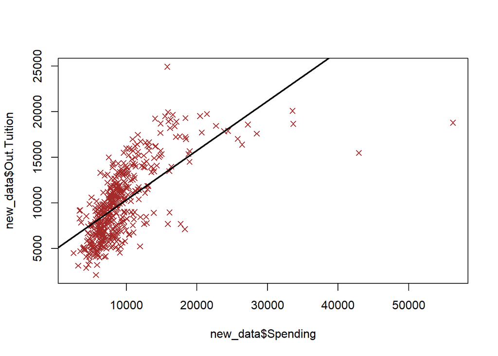

### Question 8:

1. Now suppose we want to make a regression that predicts tuition cost from the size of the student body. Make a linear model for `Size` versus `Out.Tuition`. Comment on the summary of the model, and plot it on an appropriate scatter plot, and use `plot( )` to look at the diagnostics. Does the model seem to be a good fit for this data?

```r
  # YOUR CODE HERE
  sizevout = lm(Out.Tuition~Size, data=tuition)
  summary(sizevout)
```

```
##
## Call:
## lm(formula = Out.Tuition ~ Size, data = tuition)
##
## Residuals:
##     Min      1Q  Median      3Q     Max
## -7899.0 -3081.2  -550.1  2347.0 16194.3
##
## Coefficients:
##               Estimate Std. Error t value Pr(>|t|)
## (Intercept) 9883.96074  147.77601  66.885  < 2e-16 ***
## Size          -0.16284    0.02514  -6.477 1.33e-10 ***
## ---
## Signif. codes:  0 '***' 0.001 '**' 0.01 '*' 0.05 '.' 0.1 ' ' 1
##
## Residual standard error: 4107 on 1278 degrees of freedom
##   (22 observations deleted due to missingness)
## Multiple R-squared:  0.03179,    Adjusted R-squared:  0.03103
## F-statistic: 41.96 on 1 and 1278 DF,  p-value: 1.329e-10
```

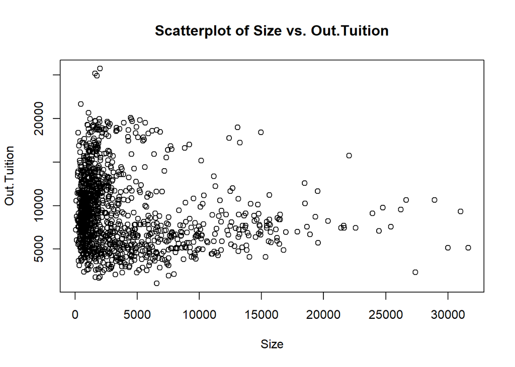

```r
  plot(tuition$Size,tuition$Out.Tuition, xlab="Size",ylab="Out.Tuition",main="Scatterplot of Size vs. Out.Tuition")
```

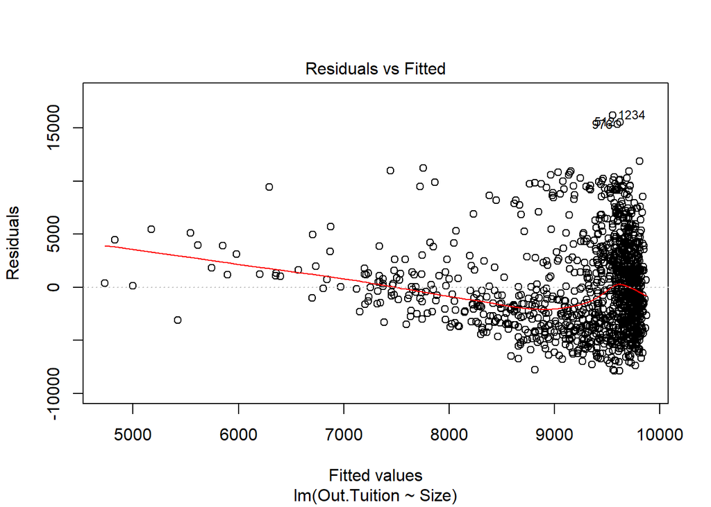

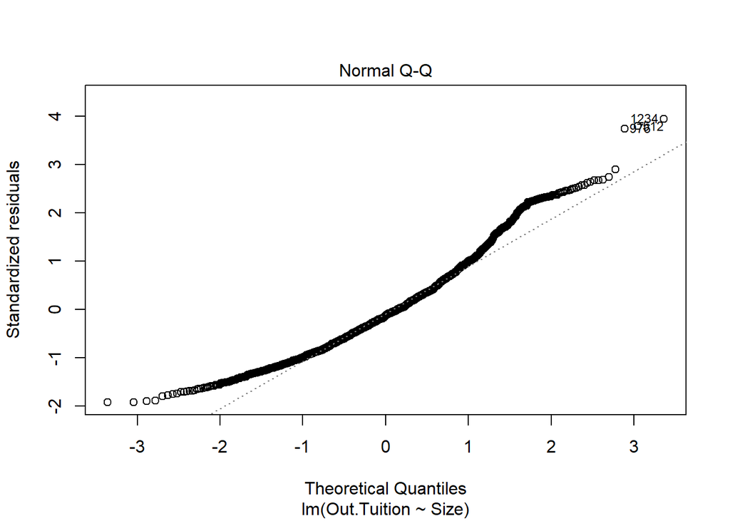

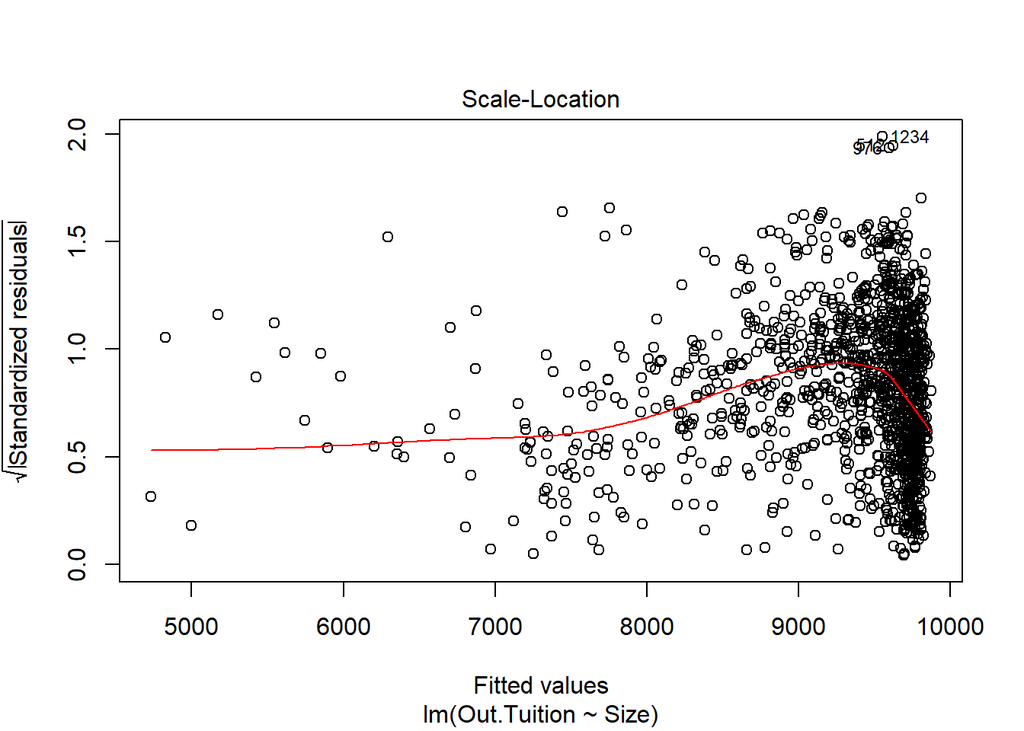

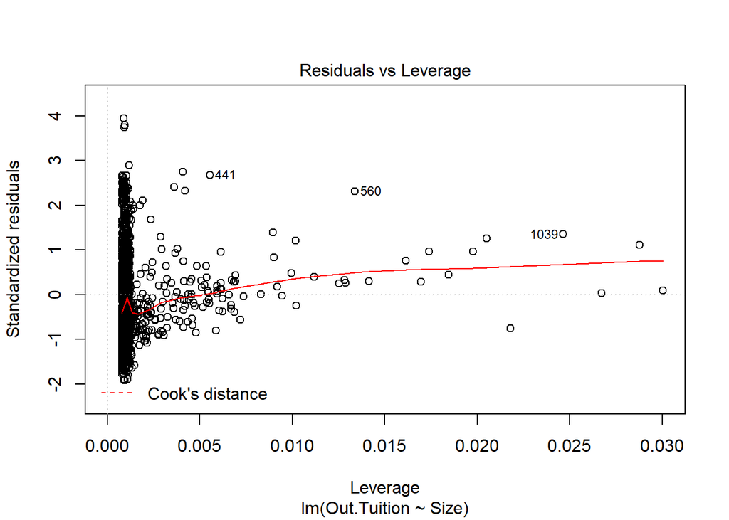

[output not shown]

```r
  plot(sizevout)
```

2. Remake your scatterplot, this time including the option `col = tuition$Public`. What did this change? Can you use this information to explain why the regression line in (a) did not fit well?

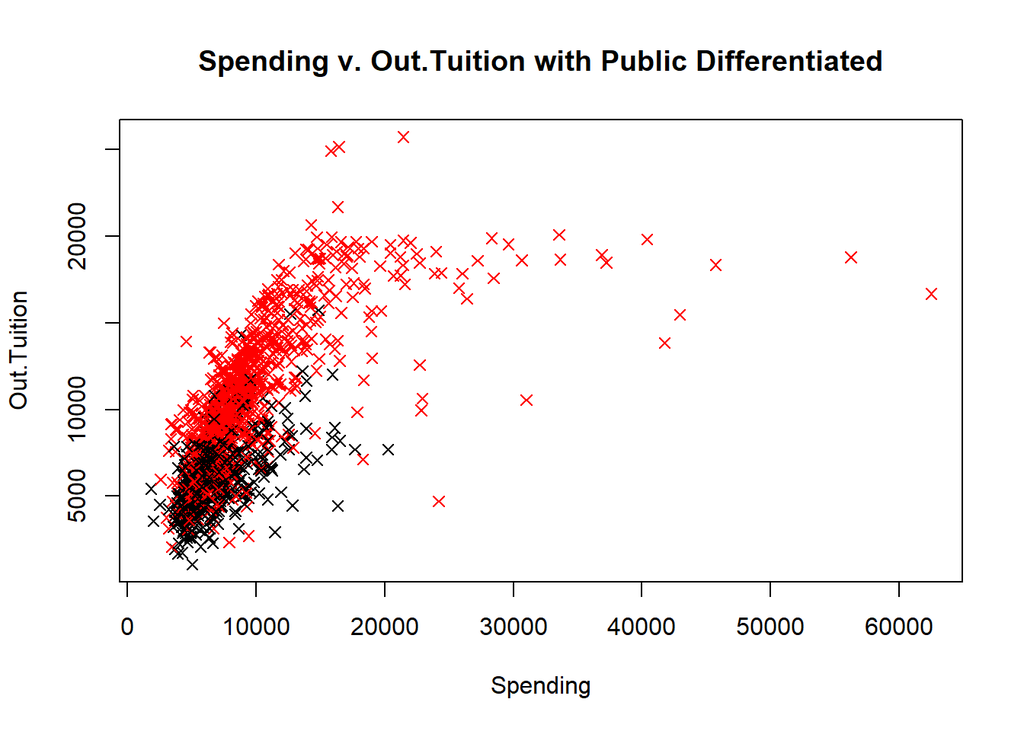

[output not shown]

```r
  # YOUR CODE HERE
 plot = plot(tuition$Spending,tuition$Out.Tuition,pch=4,col= tuition$Public, main="Spending v. Out.Tuition with Public Differentiated",xlab="Spending",ylab="Out.Tuition")
```

3. Make separate linear regressions of `Size` versus `Out.Tuition` for private schools and for public schools. Plot both of these, appropriately colored, on your scatterplot. Comment on the output and diagnostics.

```r
  # YOUR CODE HERE
  private = tuition[tuition$Public == 2,]
  lm_private = lm(Out.Tuition~Size, data=private)
  summary(lm_private)
```

```
##
## Call:
## lm(formula = Out.Tuition ~ Size, data = private)
##
## Residuals:
##      Min       1Q   Median       3Q      Max
## -19804.4  -2416.1   -328.7   2257.0  14616.7
##
## Coefficients:
##              Estimate Std. Error t value Pr(>|t|)
## (Intercept) 1.026e+04  1.817e+02  56.449  < 2e-16 ***
## Size        4.342e-01  6.940e-02   6.255 6.37e-10 ***
## ---
## Signif. codes:  0 '***' 0.001 '**' 0.01 '*' 0.05 '.' 0.1 ' ' 1
##
## Residual standard error: 3922 on 823 degrees of freedom
##   (7 observations deleted due to missingness)
## Multiple R-squared:  0.04539,    Adjusted R-squared:  0.04423
## F-statistic: 39.13 on 1 and 823 DF,  p-value: 6.366e-10
```

```r
  public = tuition[tuition$Public == 1,]
  lm_public = lm(Out.Tuition~Size, data=public)
  summary(lm_public)
```

```
##
## Call:
## lm(formula = Out.Tuition ~ Size, data = public)
##
## Residuals:
##     Min      1Q  Median      3Q     Max
## -4998.1 -1297.3  -181.9  1021.3  9355.3
##
## Coefficients:
##              Estimate Std. Error t value Pr(>|t|)
## (Intercept) 5.051e+03  1.506e+02  33.530   <2e-16 ***
## Size        1.509e-01  1.636e-02   9.223   <2e-16 ***
## ---
## Signif. codes:  0 '***' 0.001 '**' 0.01 '*' 0.05 '.' 0.1 ' ' 1
##
## Residual standard error: 1967 on 453 degrees of freedom
##   (15 observations deleted due to missingness)
## Multiple R-squared:  0.1581, Adjusted R-squared:  0.1562
## F-statistic: 85.07 on 1 and 453 DF,  p-value: < 2.2e-16
```

[output not shown]

## Multiple Linear Regression

We have seen that a college’s tuition relates to its size, its spending per student, and its average SAT score. We have also seen that this relationship may change based on whether the school is public or private. Ideally, instead of making separate regressions for each relationship, we could combine them all into a multiple regression. Fortunately, **R** makes this easy with `lm()`.

### Question 9:

1. Run the following code to perform a multiple regression. Interpret the results.

```r
  mult.1 <- lm(Out.Tuition ~ Size + Avg.SAT + Avg.ACT + Spending + Acc.Rate, data = tuition)

  summary(mult.1)
```

```
##
## Call:
## lm(formula = Out.Tuition ~ Size + Avg.SAT + Avg.ACT + Spending +
##     Acc.Rate, data = tuition)
##
## Residuals:
##      Min       1Q   Median       3Q      Max
## -12382.1  -1661.8   -145.9   1534.7  10590.3
##
## Coefficients:
##               Estimate Std. Error t value Pr(>|t|)
## (Intercept) -7.112e+03  1.463e+03  -4.863 1.59e-06 ***
## Size        -1.989e-01  2.343e-02  -8.488 2.87e-16 ***
## Avg.SAT      6.032e+00  2.439e+00   2.473  0.01377 *
## Avg.ACT      2.979e+02  1.040e+02   2.866  0.00435 **
## Spending     3.802e-01  2.994e-02  12.700  < 2e-16 ***
## Acc.Rate     2.193e+03  9.047e+02   2.424  0.01574 *
## ---
## Signif. codes:  0 '***' 0.001 '**' 0.01 '*' 0.05 '.' 0.1 ' ' 1
##
## Residual standard error: 2512 on 463 degrees of freedom
##   (833 observations deleted due to missingness)
## Multiple R-squared:  0.5978, Adjusted R-squared:  0.5934
## F-statistic: 137.6 on 5 and 463 DF,  p-value: < 2.2e-16
```

[output not shown]

2. We can also mix and match continuous variables with categorical ones. Let’s add `Public` to the regression. The following two models are slightly different, but give essentially identical output. What is the difference between them, and why is it important even though the output still the same?

```r
  mult.2 <- lm(Out.Tuition ~ Size + Avg.SAT + Avg.ACT + Spending + Public, data = tuition)
  mult.3 <- lm(Out.Tuition ~ Size + Avg.SAT + Avg.ACT + Spending + factor(Public), data = tuition)
  summary(mult.2)
```

```
##
## Call:
## lm(formula = Out.Tuition ~ Size + Avg.SAT + Avg.ACT + Spending +
##     Public, data = tuition)
##
## Residuals:
##     Min      1Q  Median      3Q     Max
## -9998.4 -1398.7    50.9  1355.7 10607.1
##
## Coefficients:
##               Estimate Std. Error t value Pr(>|t|)
## (Intercept) -9.316e+03  1.088e+03  -8.561  < 2e-16 ***
## Size        -3.002e-03  2.912e-02  -0.103 0.917941
## Avg.SAT      8.122e+00  2.210e+00   3.675 0.000265 ***
## Avg.ACT      1.193e+02  9.639e+01   1.238 0.216389
## Spending     3.075e-01  2.747e-02  11.194  < 2e-16 ***
## Public       3.380e+03  3.351e+02  10.087  < 2e-16 ***
## ---
## Signif. codes:  0 '***' 0.001 '**' 0.01 '*' 0.05 '.' 0.1 ' ' 1
##
## Residual standard error: 2288 on 466 degrees of freedom
##   (830 observations deleted due to missingness)
## Multiple R-squared:  0.6672, Adjusted R-squared:  0.6637
## F-statistic: 186.9 on 5 and 466 DF,  p-value: < 2.2e-16
```

```r
  summary(mult.3)
```

```
##
## Call:
## lm(formula = Out.Tuition ~ Size + Avg.SAT + Avg.ACT + Spending +
##     factor(Public), data = tuition)
##
## Residuals:
##     Min      1Q  Median      3Q     Max
## -9998.4 -1398.7    50.9  1355.7 10607.1
##
## Coefficients:
##                   Estimate Std. Error t value Pr(>|t|)
## (Intercept)     -5.936e+03  1.002e+03  -5.921 6.21e-09 ***
## Size            -3.002e-03  2.912e-02  -0.103 0.917941
## Avg.SAT          8.122e+00  2.210e+00   3.675 0.000265 ***
## Avg.ACT          1.193e+02  9.639e+01   1.238 0.216389
## Spending         3.075e-01  2.747e-02  11.194  < 2e-16 ***
## factor(Public)2  3.380e+03  3.351e+02  10.087  < 2e-16 ***
## ---
## Signif. codes:  0 '***' 0.001 '**' 0.01 '*' 0.05 '.' 0.1 ' ' 1
##
## Residual standard error: 2288 on 466 degrees of freedom
##   (830 observations deleted due to missingness)
## Multiple R-squared:  0.6672, Adjusted R-squared:  0.6637
## F-statistic: 186.9 on 5 and 466 DF,  p-value: < 2.2e-16
```

[output not shown]

3. It is still important to check diagnostics in a multiple regression, although it can be harder to track down the source of problems. Use `plot( )` to look at diagnostics for `mult.3`, and comment.

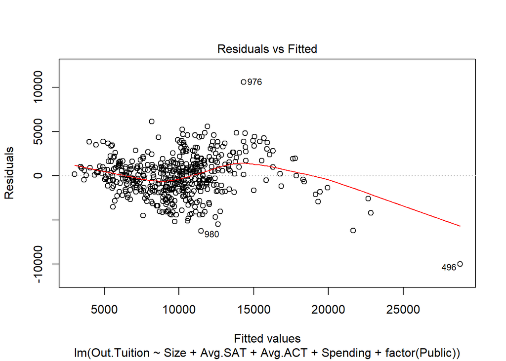

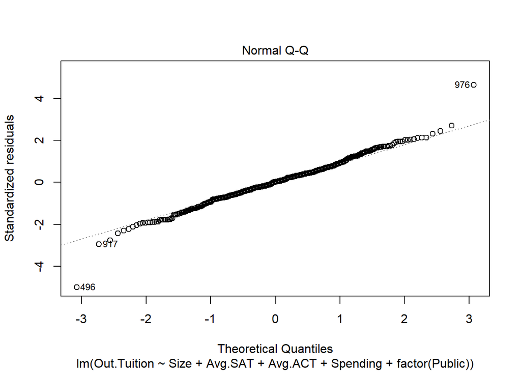

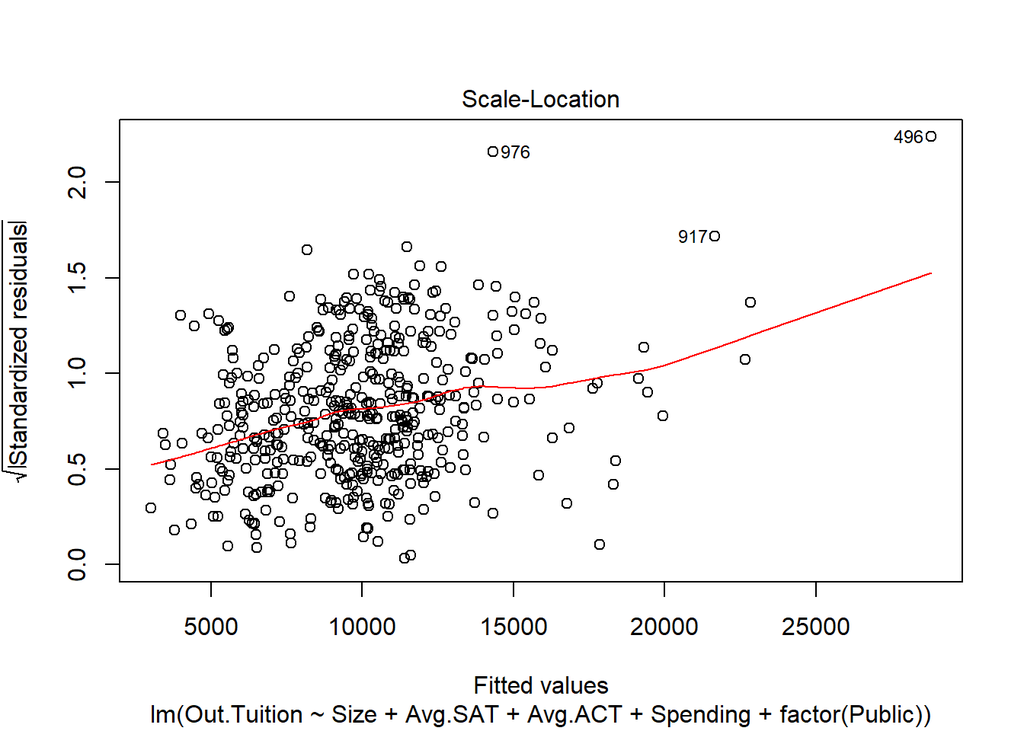

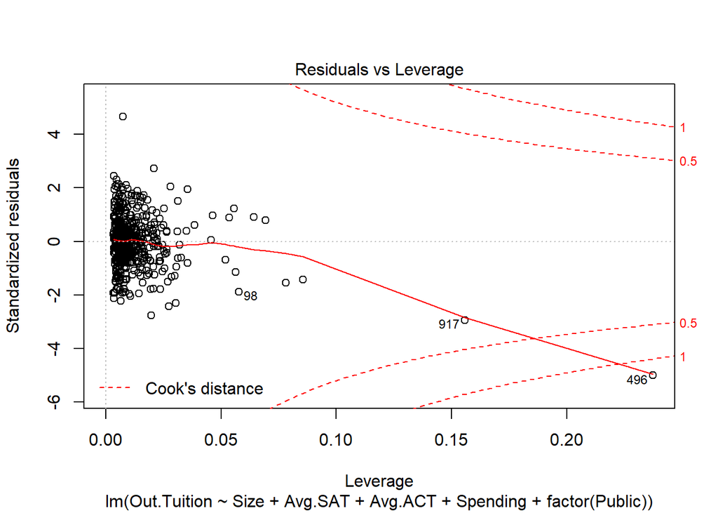

[output not shown]

```r
  # YOUR CODE HERE
  plot(mult.3)
```

### Question 10:

1. A big problem in multiple regression is *collinearity*, which means that two or more explanatory variables are correlated with each other. Read the documentation for `pairs( )`, and then use it on the variables involved in `mult.3`. *Hint: You can use the option `col = tuition$Public` in `pairs( )`*

```r
  # YOUR CODE HERE

  pairs( ~ Size + Avg.SAT + Avg.ACT + Spending + factor(Public), data = tuition,lower.panel=NULL,col = tuition$Public)
```

[output not shown]

2. Do any of the variables seem strongly related? What is their correlation?

```r
  # YOUR CODE HERE
  summary(lm(Avg.SAT~Avg.ACT, data=tuition))
  summary(lm(Out.Tuition~Avg.ACT,data=tuition))
```

[output not shown]

[output not shown]

3. Explain in your own words why the correlation between the variables you discussed in (a) could be a problem.

```
having correlation within data causes alot of effects on the data. One big effect though is if two predictor values are correlated, one will lose relation to the respons variable. FOr example, the t-value for Avg.Act and Out.Tuition is highly significant without Avg.SAT in the summary, but when Avg.SAT is included, ACT becomes insignificant in relation to Out.Tuition.
```

## Sneak Preview: Interaction Terms

We saw in 12c that whether a school is public or private can affect not only the tuition, but also how the tuition relates to other variables. In a multiple regression, this effect can be captured through interaction terms, which are expressed by `var1:var2`, and measure how much one variable changes the effect of the other.

Read the following paragraph from the documentation `?formula` for some shortcuts for including interactions:

```
In addition to + and :, a number of other operators are useful in model formulae. The * operator denotes factor crossing: a*b interpreted as a+b+a:b. The ^ operator indicates crossing to the specified degree. For example (a+b+c)^2 is identical to (a+b+c)*(a+b+c) which in turn expands to a formula containing the main effects for a, b and c together with their second-order interactions. The %in% operator indicates that the terms on its left are nested within those on the right. For example a + b %in% a expands to the formula a + a:b. The - operator removes the specified terms, so that (a+b+c)^2 - a:b is identical to a + b + c + b:c + a:c. It can also used to remove the intercept term: when fitting a linear model y ~ x - 1 specifies a line through the origin. A model with no intercept can be also specified as y ~ x + 0 or y ~ 0 + x.
```

### Question 11:

Create your own multiple regression that predicts tuition from whichever variables you choose, as well as some interaction terms between `Public` and other variables. Don’t worry about using any official methods to pick variables; simply try a few things and choose the model that seems best. Interpret the results; in particular, think very carefully about what the coefficient for an interaction term with `Public` might mean.

```r
  # YOUR CODE HERE
mult.own <- lm(formula = Out.Tuition ~ Accepted + Avg.SAT + Spending:factor(Public), data = tuition)

summary(mult.own)
```

```
##
## Call:
## lm(formula = Out.Tuition ~ Accepted + Avg.SAT + Spending:factor(Public),
##     data = tuition)
##
## Residuals:
##      Min       1Q   Median       3Q      Max
## -14391.1  -1408.3    100.4   1417.8  10420.3
##
## Coefficients:
##                            Estimate Std. Error t value Pr(>|t|)
## (Intercept)              -2.821e+03  7.999e+02  -3.527 0.000447 ***
## Accepted                  1.434e-01  4.457e-02   3.219 0.001345 **
## Avg.SAT                   1.141e+01  9.392e-01  12.146  < 2e-16 ***
## Spending:factor(Public)1 -2.010e-01  3.800e-02  -5.290 1.62e-07 ***
## Spending:factor(Public)2  2.841e-01  2.203e-02  12.898  < 2e-16 ***
## ---
## Signif. codes:  0 '***' 0.001 '**' 0.01 '*' 0.05 '.' 0.1 ' ' 1
##
## Residual standard error: 2391 on 740 degrees of freedom
##   (557 observations deleted due to missingness)
## Multiple R-squared:  0.6477, Adjusted R-squared:  0.6458
## F-statistic: 340.2 on 4 and 740 DF,  p-value: < 2.2e-16
```

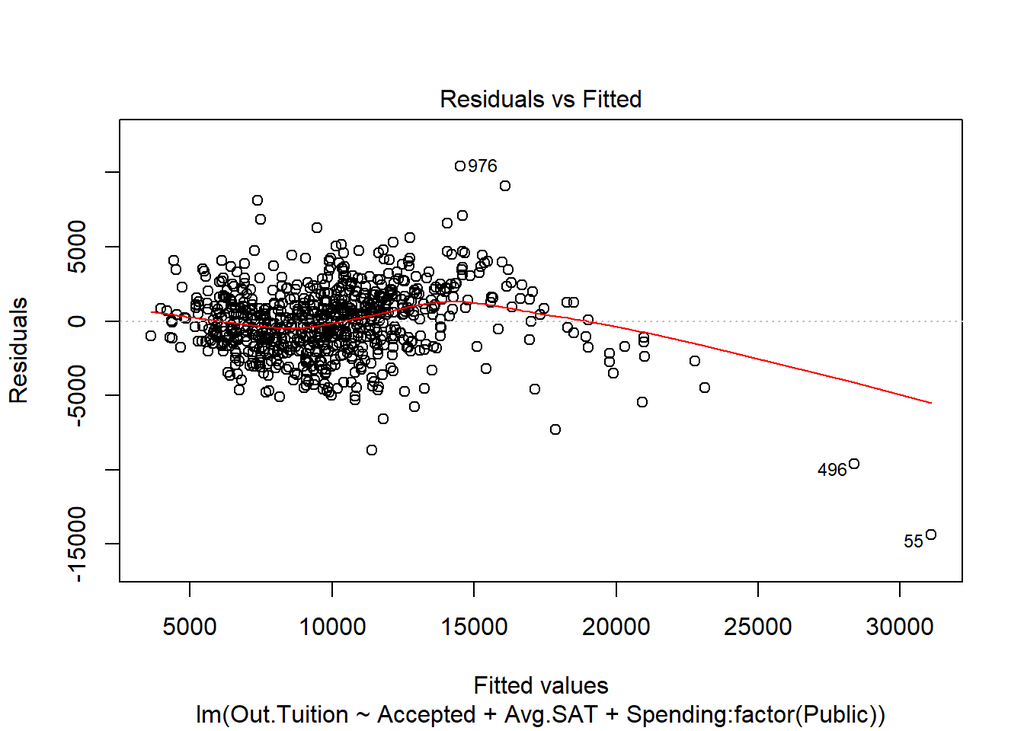

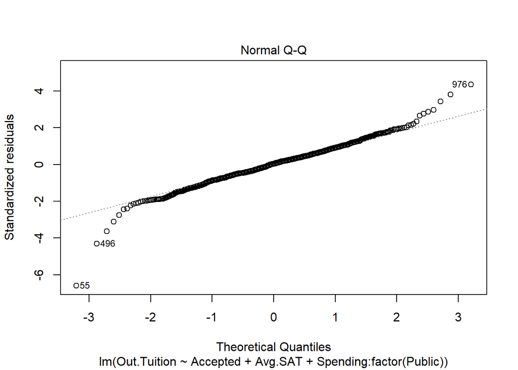

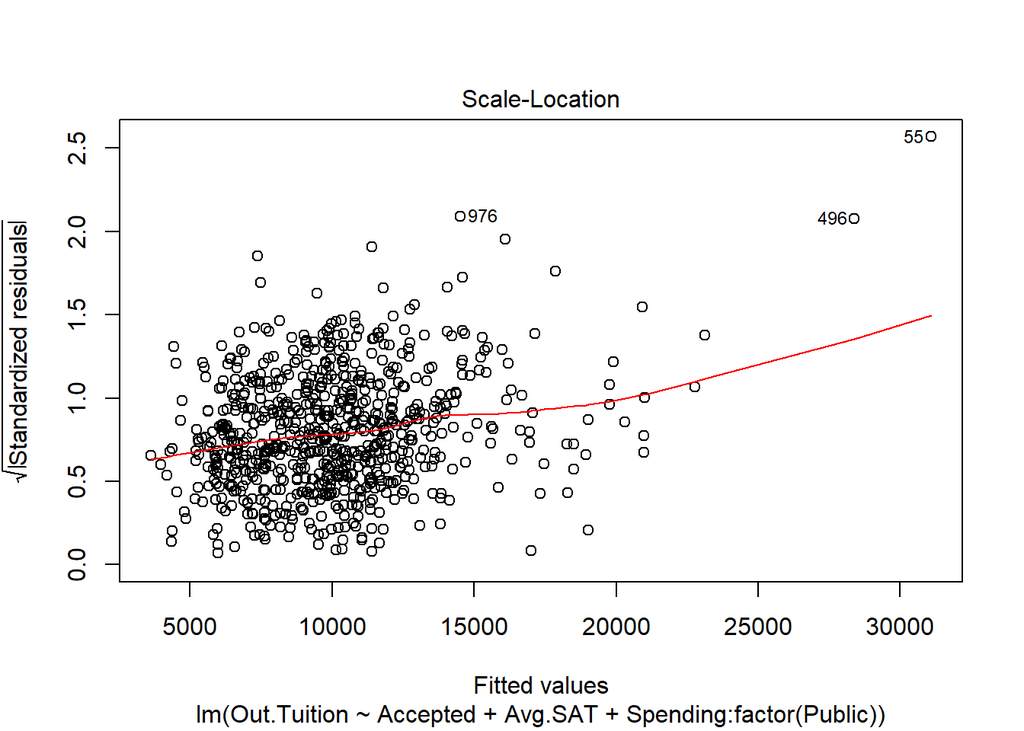

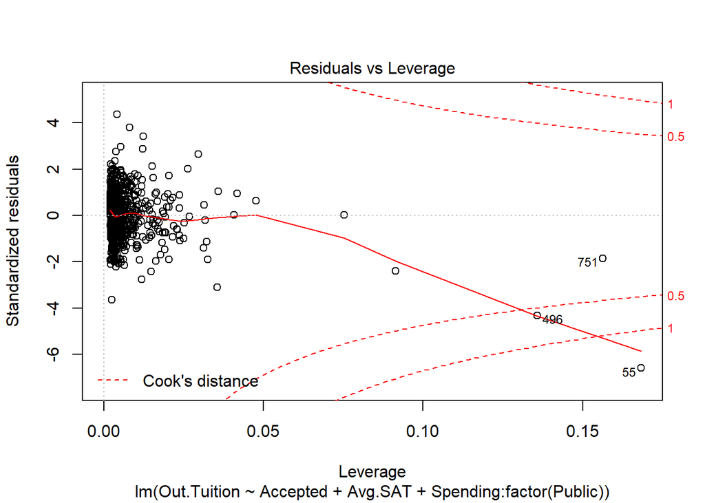

[output not shown]

```r
plot(mult.own)
```